# HW2-EDA with R - Part1: Plotting

# i) Percentage of Women & Men Population Distribution For US Across Regions

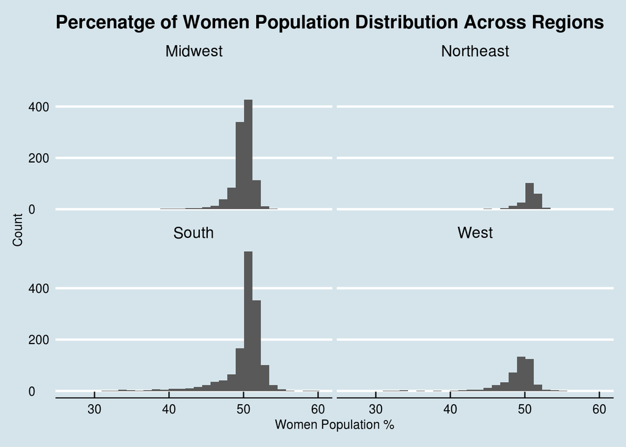

```r
library(ggthemes)

# Percentage Distribution of Women Population Across Regions
g2 <- ggplot(county_df, aes(x=Women/TotalPop*100)) + geom_histogram() + labs(
    x = "Women Population %",                                                  # x axis title
    y = "Count",                                                               # y axis title
    title="Percenatge of Women Population Distribution Across Regions"         # main title of figure
) + facet_wrap(~Region)
g2 + theme_economist() + scale_colour_economist()
```

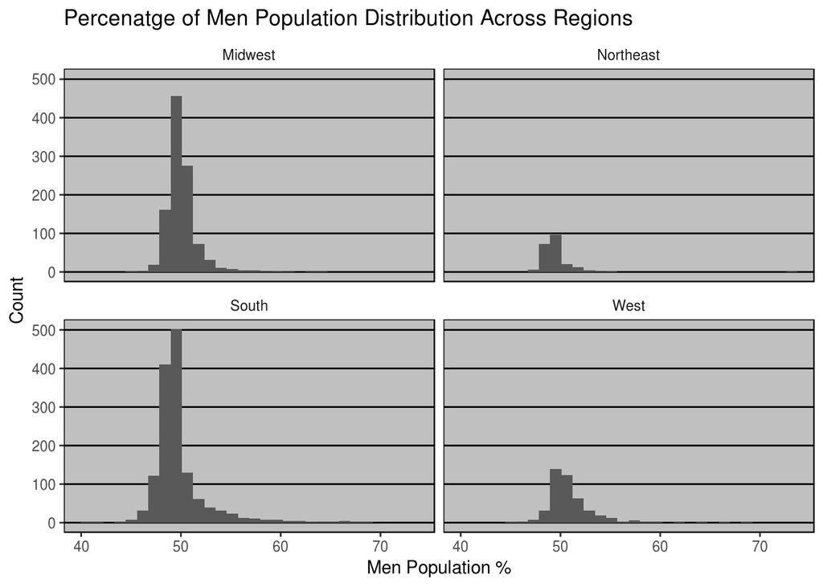

```r
# Percentage Distribution of Men Population Across Regions
g2 <- ggplot(county_df, aes(x=Men/TotalPop*100)) + geom_histogram() + labs(
    x = "Men Population %",                                                   # x axis title
    y = "Count",                                                              # y axis title
    title="Percenatge of Men Population Distribution Across Regions"          # main title of figure
) + facet_wrap(~Region)
g2 + theme_excel() + scale_colour_excel()
```

# ii) Distribution of Total Population & Income Per Capita In Michigan

There appears to be a linearity for the two variables Total Population and Income Per Capita, in both the Lower & Upper Peninsula with some of the outliers scattered within the data sets. The outliers for the Lower Peninsula in describing the relationship between Total Population and Income Per Capita seems to be more than the outliers for the data points of Upper Peninsula.

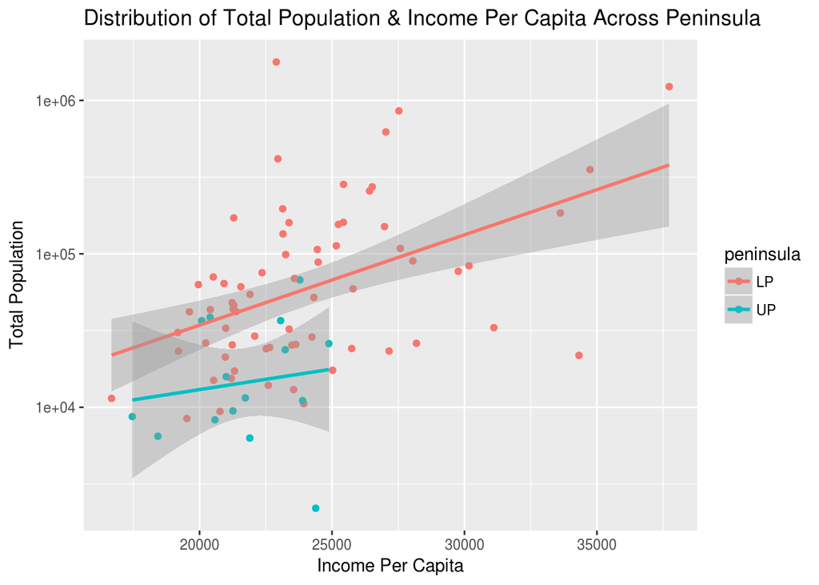

```r
ggplot(county_MI, aes(IncomePerCap, TotalPop, color = peninsula)) + geom_point() + scale_y_log10() + geom_smooth(method = "lm") + labs(
    x = "Income Per Capita",                                                              # x axis title
    y = "Total Population",                                                               # y axis title
    title="Distribution of Total Population & Income Per Capita Across Peninsula"         # main title of figure
)
```

# iii) Employment Distribution Across Total Population Across UP & LP in Michigan

There seems to have a positive correlation between Employment Distribution across the Total Population in both the Upper & Lower Peninsula in Michigan.

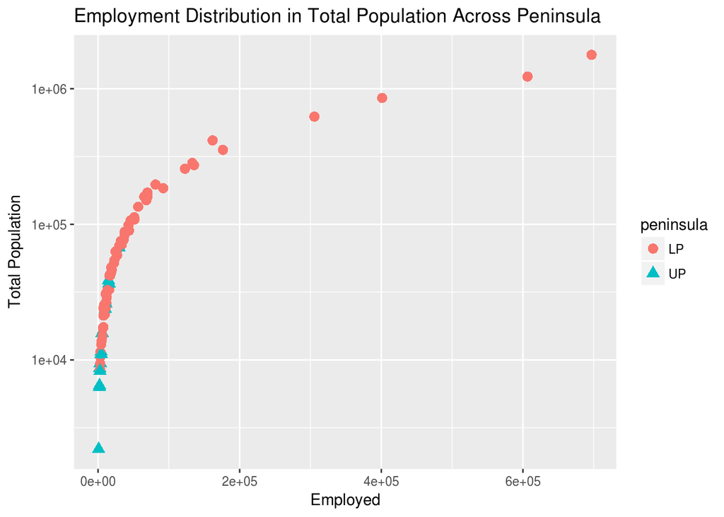

```r
ggplot(county_MI, aes(Employed, TotalPop, color = peninsula)) + geom_point() + scale_y_log10() + geom_point(aes(shape = peninsula), size = 3) + labs(
    x = "Employed",                                                              # x axis title
    y = "Total Population",                                                      # y axis title
    title="Employment Distribution in Total Population Across Peninsula"         # main title of figure
)
```

# iv) Unemployment Distribution Across Total Population Across UP & LP in Michigan

The Unemployment Distribution with respect to the Total Population seems to have a scattered relationship amongst the datapoints within the datasets and hence from the visuals of the graphical results we can conclude that the Unemployment Distribution and the Total Population across both the Upper & Lower Peninsula has a weak correlation.

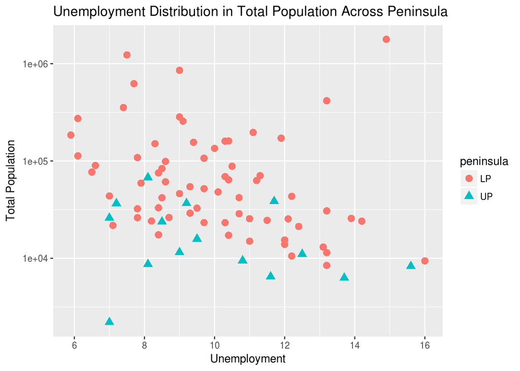

```r
ggplot(county_MI, aes(Unemployment, TotalPop, color = peninsula)) + geom_point() + scale_y_log10() + geom_point(aes(shape = peninsula), size = 3) + labs(
    x = "Unemployment",                                                            # x axis title
    y = "Total Population",                                                        # y axis title
    title="Unemployment Distribution in Total Population Across Peninsula"         # main title of figure
)
```

# v) Men Population Distribution in US Across Regions

The Median of the percentage of Men Population Distribution across the various Regions such as the Midwest, Northeast, South, and West is in and around 50, with the upper whisker’s outliers extending almost near 70 for South & West Region. And the lower whisker’s outliers range extending almost near to 40 for South Region.

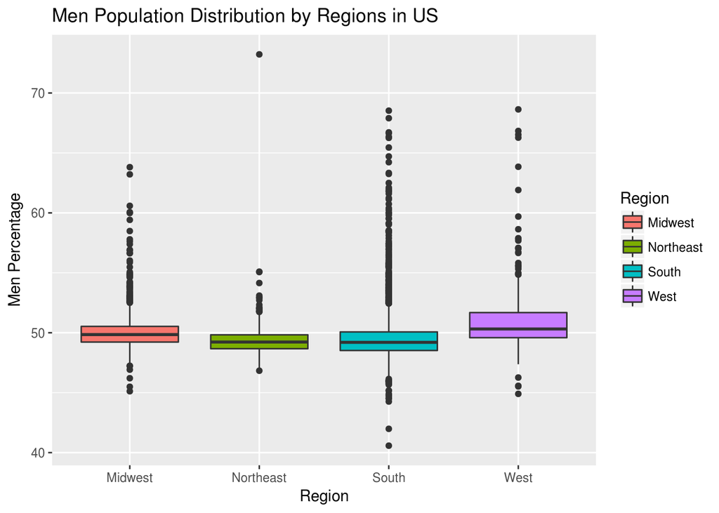

```r
ggplot(county_df, aes(x=Region, y=PercentageMen, fill = Region)) + geom_boxplot() + labs(
    x = "Region",                                                    # x axis title
    y = "Men Percentage",                                            # y axis title
    title = "Men Population Distribution by Regions in US"           # main title of figure
)
```

# vi) Women Population Distribution in US Across Regions

The Median of the percentage of Women Population Distribution across the various Regions such as the Midwest, Northeast, South, and West is in and around 50, with the upper whisker’s outliers extending almost near to 60 for South & near to 55 for the West Region. And the lower whisker’s outliers range extending almost near to 30 for both the South & West Region.

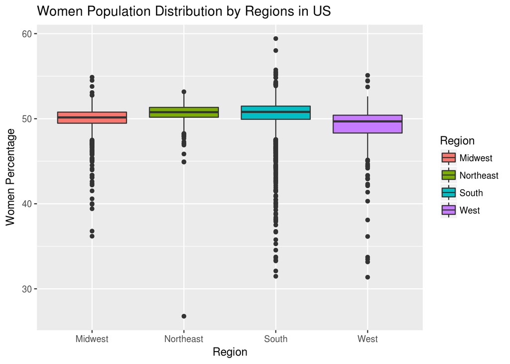

```r
ggplot(county_df, aes(x=Region, y=PercentageWomen, fill = Region)) + geom_boxplot() + labs(
    x = "Region",                                                    # x axis title
    y = "Women Percentage",                                          # y axis title
    title = "Women Population Distribution by Regions in US"         # main title of figure
)
```